# Отчёт по прохождению 3 этапа внешнего курса

Продвинутые темы

Автор

принадлежность

Терентеевская Светлана Александровна, Student

Российский университет дружбы народов

Дата публикации

2026-05-15

# Информация

## Докладчик

- Терентеевская Светлана Александровна
- Группа НКАбд-05-25, студент бакалавра
- Российский университет дружбы народов им. П. Лумумбы
- 1032253498@rudn.ru
- https://github.com/SvetlanaTerenteevskaya

# Вводная часть

## Цель работы

Пройти 3 этап курса “Введение в Linux” на платформе Stepik и ознакомиться с функционалом Linux.

## Задание

Просмотреть видео и на основе полученной информации пройти тестовые и интерактивнные задания.

# Теоретическое введение

Линукс - в части случаев GNU/Linux — семейство Unix-подобных операционных систем на базе ядра Linux, включающих тот или иной набор утилит и программ проекта GNU, и, возможно, другие компоненты. Как и ядро Linux, системы на его основе, как правило, создаются и распространяются в соответствии с моделью разработки свободного и открытого программного обеспечения. Linux-системы распространяются в основном бесплатно в виде различных дистрибутивов — в форме, готовой для установки и удобной для сопровождения и обновлений, — и имеющих свой набор системных и прикладных компонентов, как свободных, так и проприетарных.

# Прохождение внешнего курса

В vim команда выхода - :q (двоеточие для командной строки, q-quit, Enter - выполнить). Остальное: q-макрос, Q-режим Ez, Esc-смена режима, а не выод (рис. 1).

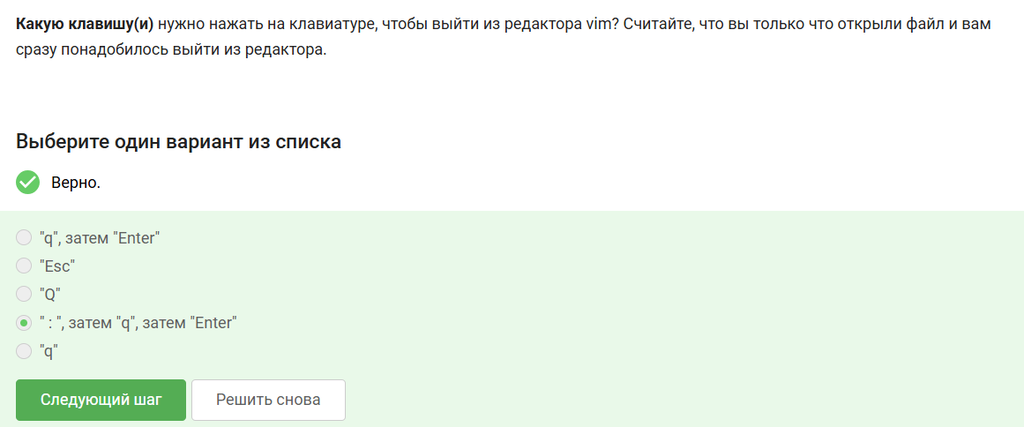

Рисунок 1: 1 задание

Последовательность любых символов кроме пробелов. Пробелов 4, значит 5 фрагметов (больших слов). W перепрыгнет через . (так как точка не пробел). w-9 нажатий, W-5, через 10 оба в конце. w - буквы, цифры, _ считаются, знаки .,=,!-отдельные слова (рис. 2).

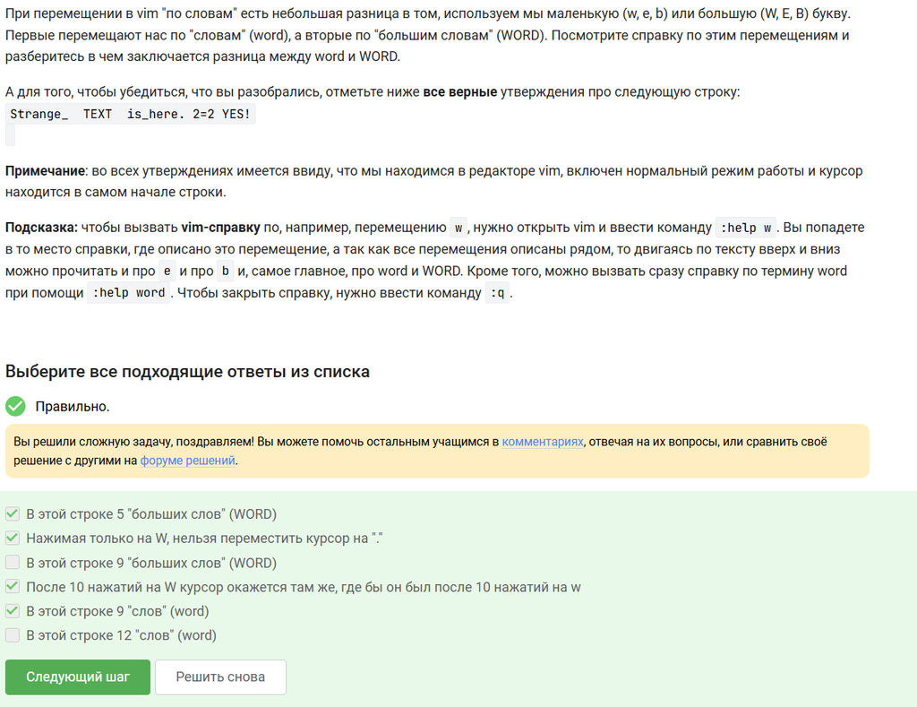

Рисунок 2: 2 задание

x2wwywPp - x удалит только о, затем 2w перейдет не туда. В итоге получится ne two three three three four five или подобное(рис. 3).

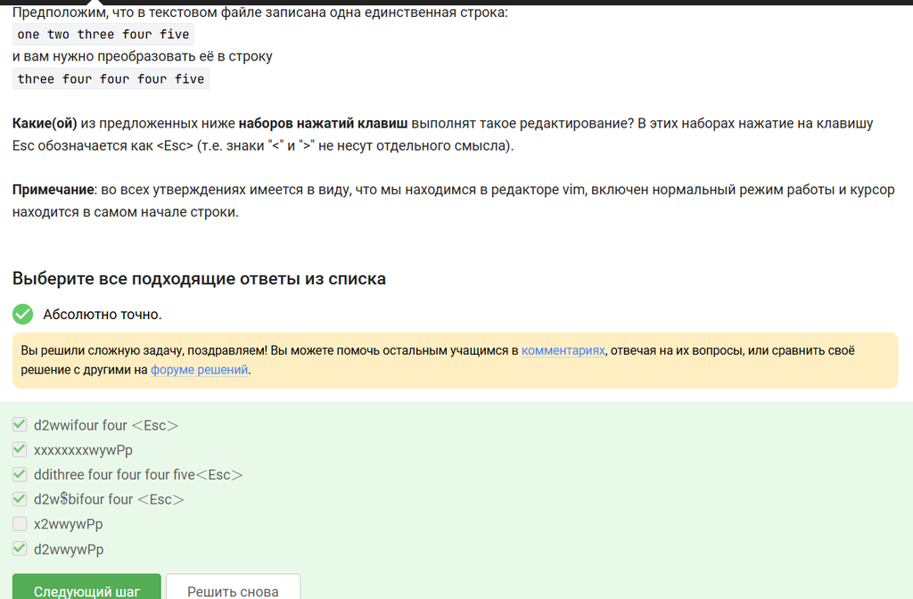

Рисунок 3: 3 задание

% - весь файл, s - замена, /Windows/Linux - что на что заменяем, без флага g - только первое вхождение в строке (рис. 4).

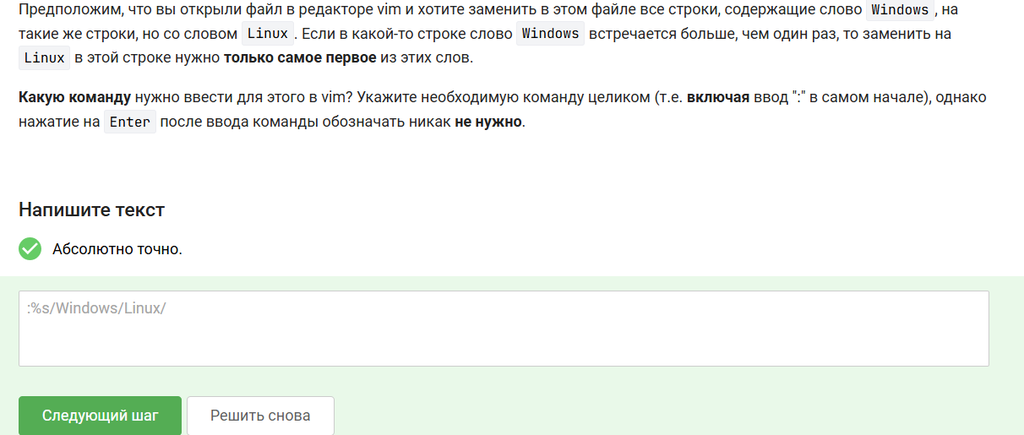

Рисунок 4: 4 задание

:q - это выход из редактора, а не из режима выделения (рис. 5).

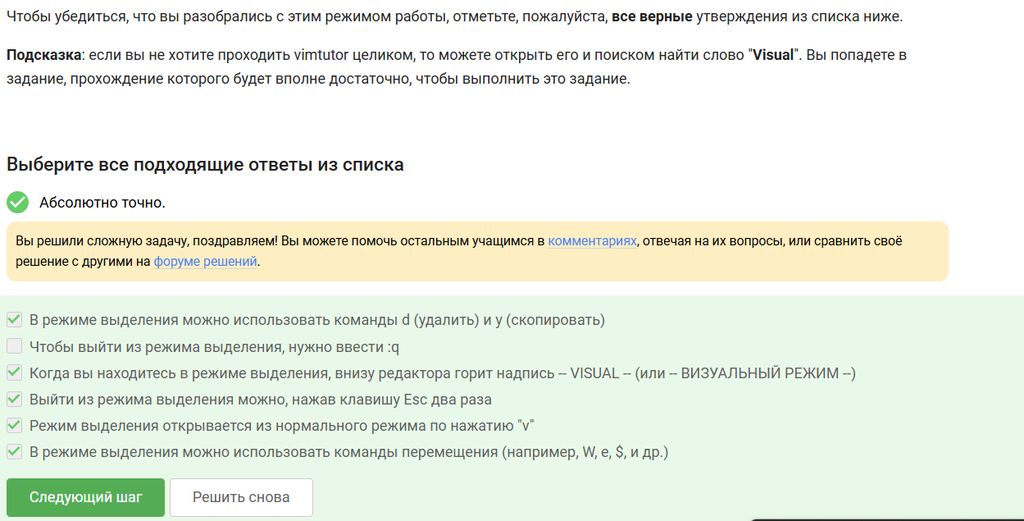

Рисунок 5: 5 задание

У каждой оболочки (bash) своя история. Новая bash не наследует историю от предыдущих, поэтому команды С - последняя bash, их и покажут стрелочки (рис. 6).

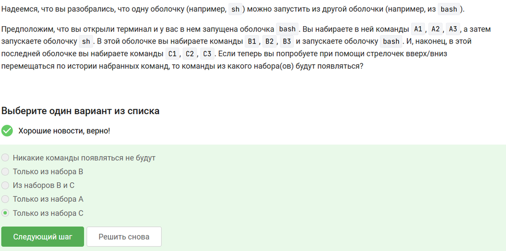

Рисунок 6: 6 задание

cd /home/bi/ файл создается там. cd /home/bi/Desktop/ не перемещает файл (рис. 7).

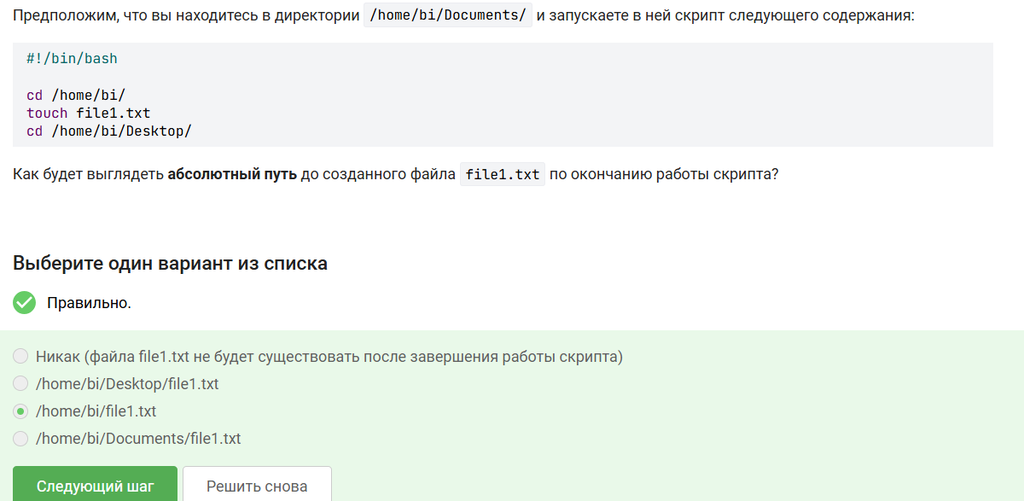

Рисунок 7: 7 задание

```
#!/bin/bash
echo "Arguments are: \$1=$1 \$2=$2"
```

Построчно:

#!/bin/bash — интерпретатор

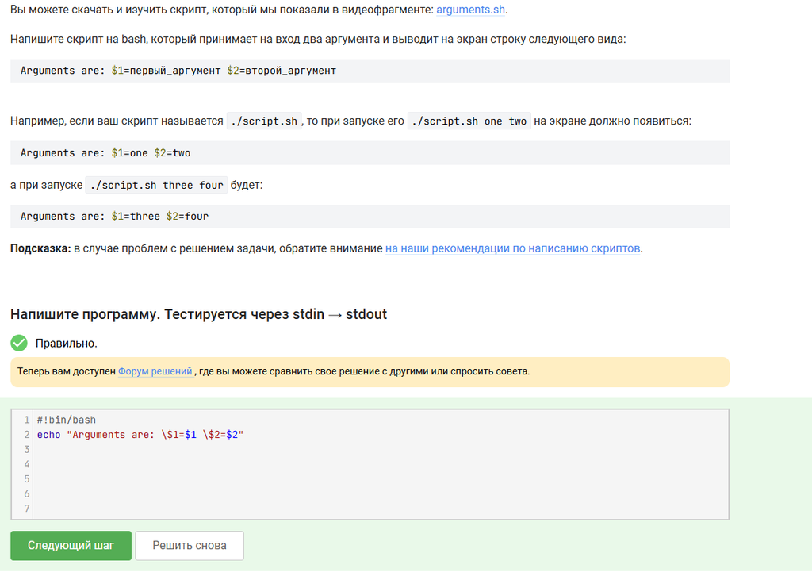

Рисунок 8: 8 задание

Имя может начинаться с буквы или *, затем буквы, цифры,*. 123variable - цифры в начале, остальные: /, -, пробел, $$, @ - недопустимы (рис. 9).

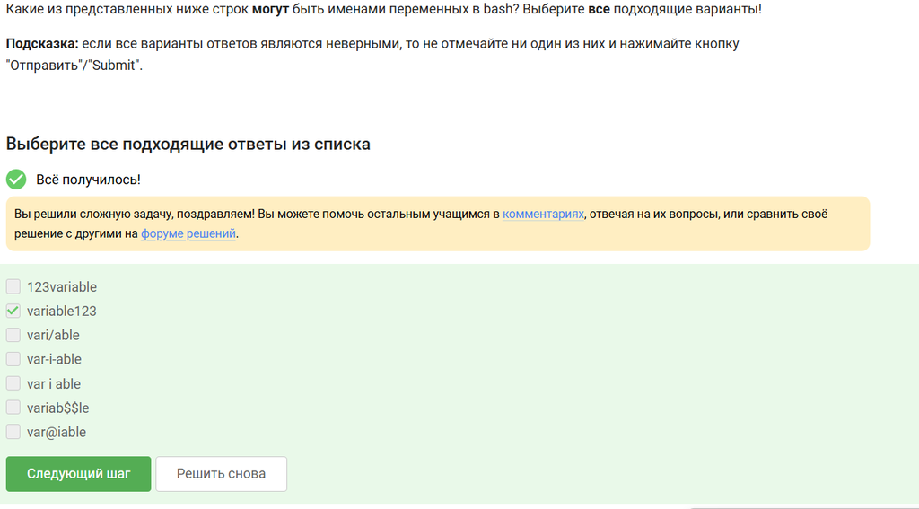

Рисунок 9: 9 задание

!(4 -le 3): 4<=3 - ложно, отрицание и ложь получается истина. $# -ge 0: $# - количество аргументов, переданных скрипту, оно всегда целое неотрицательное, а -ge 0 значит больше или равно 0, значит условие всегда истинно (рис. 10).

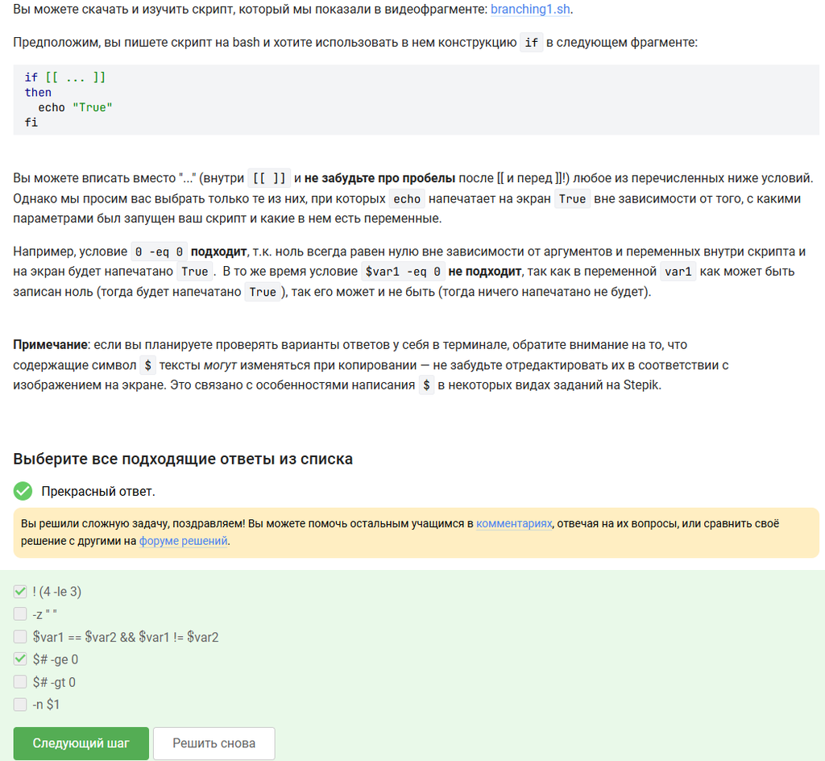

Рисунок 10: 10 задание

```
#!/bin/bash
case $1 in
  0) echo "No students" ;;
  1) echo "1 student" ;;
  2|3|4) echo "$1 students" ;;
  *) echo "A lot of students" ;;
esac
```

Построчно:

case $1 in — проверяем первый аргумент

0. echo “No students” ;; — если 0, вывести “No students”
1. echo “1 student” ;; — если 1, вывести “1 student”

2|3|4) echo “$1 students” ;; — если 2, 3 или 4, вывести “X students”

*) echo “A lot of students” ;; — если любое другое число, вывести “A lot of students”

esac — конец конструкции case (рис. 11).

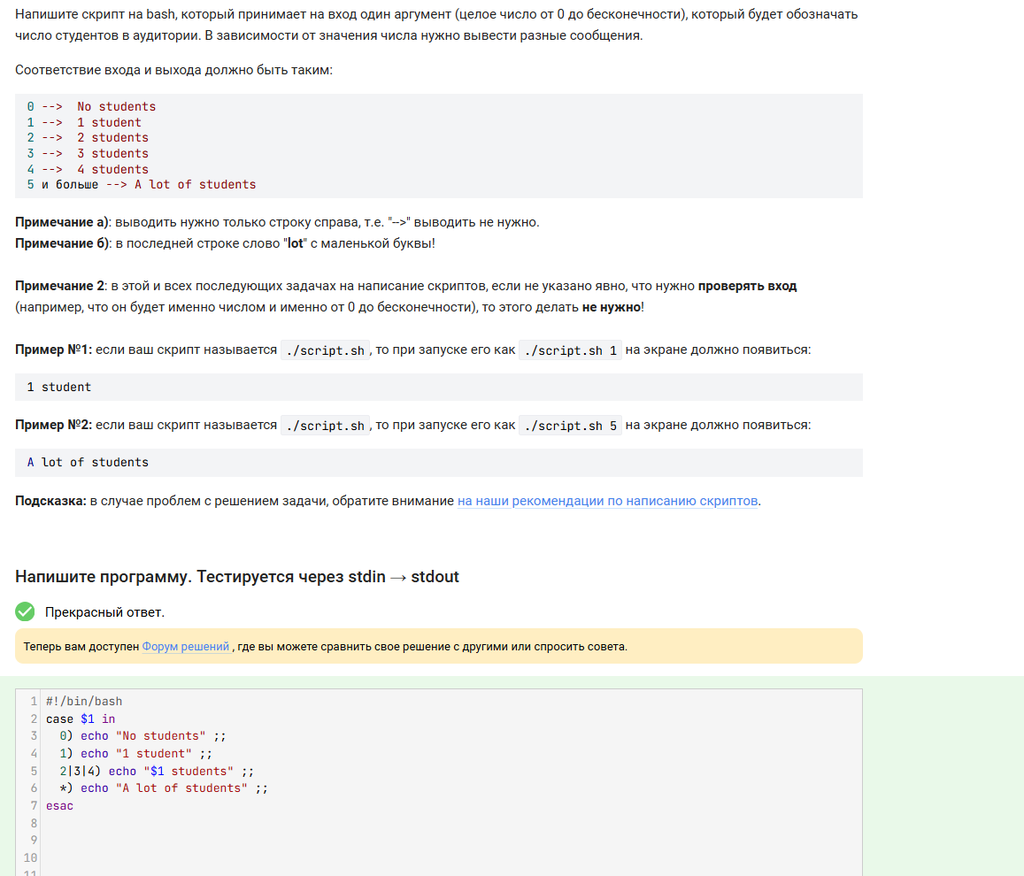

Рисунок 11: 11 задание

Оба значения (var=3 и var=5) не подпадают ни под одно из условий (-gt 5, -lt 3, -eq 4), поэтому оба раза выполняется ветка else, печатающая four (рис. 12).

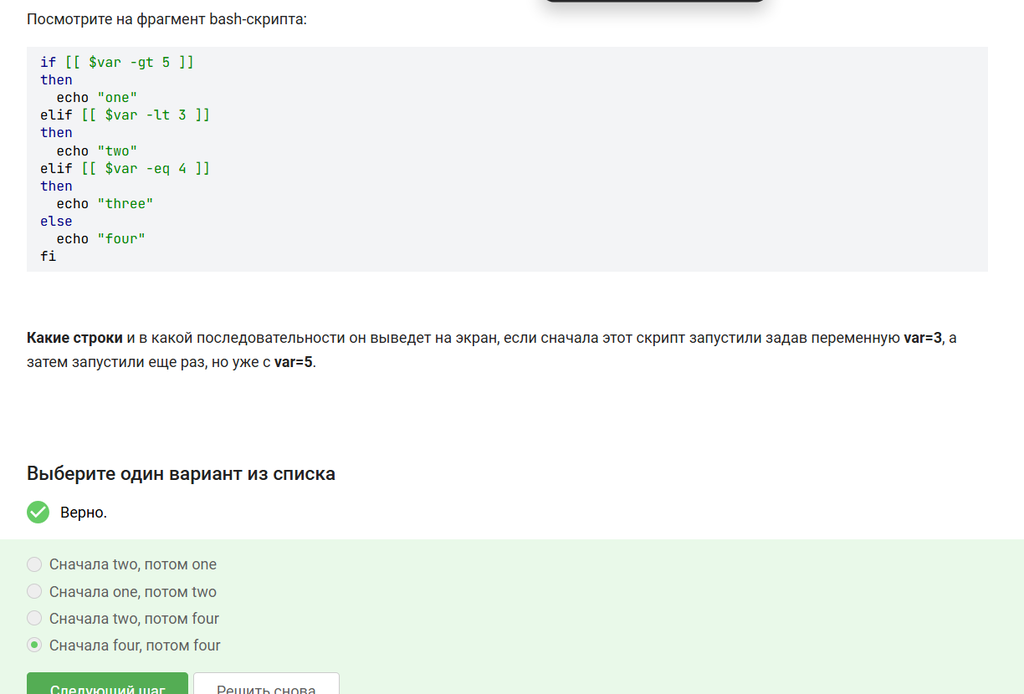

Рисунок 12: 12 задание

```
while true; do
  echo "enter your name:"
  read name
  [ -z "$name" ] && echo "bye" && exit
  echo "enter your age:"
  read age
  [ "$age" -eq 0 ] && echo "bye" && exit
  if [ "$age" -le 16 ]; then group="child"
  elif [ "$age" -le 25 ]; then group="youth"
  else group="adult"
  fi
  echo "$name, your group is $group"
done
```

Построчно:

while true; do — бесконечный цикл

echo “enter your name:” — приглашение ввести имя

read name — читаем имя

[ -z “$name” ] && echo “bye” && exit — если имя пустое, выводим “bye” и выходим

echo “enter your age:” — приглашение ввести возраст

read age — читаем возраст

[ “$age” -eq 0 ] && echo “bye” && exit — если возраст 0, выводим “bye” и выходим

if [ “$age” -le 16 ]; then group=“child” — если возраст ≤16, группа child

elif [ “$age” -le 25 ]; then group=“youth” — иначе если ≤25, группа youthelse group=“adult” — иначе (старше 25) группа adult

echo “$name, your group is $group” — выводим результат

done — конец цикла(рис. 13, рис. 14).

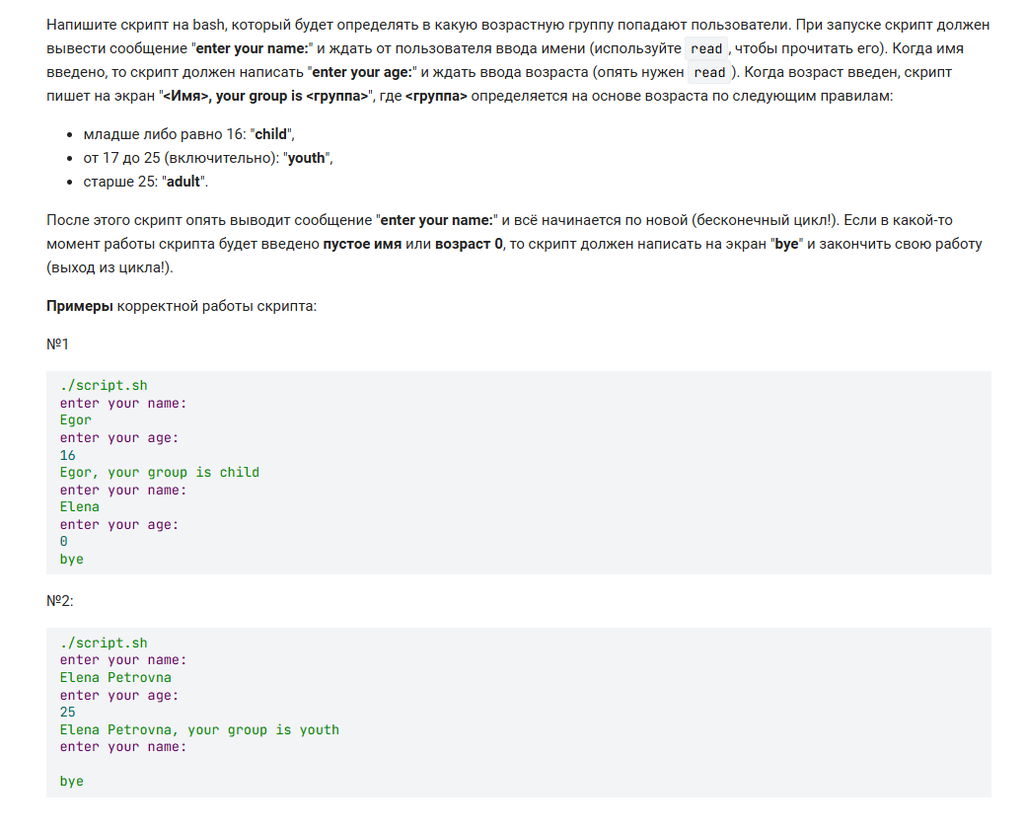

Рисунок 13: 13 задание

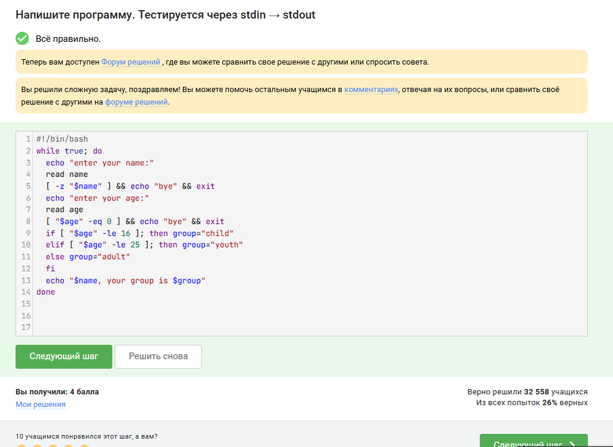

Рисунок 14: 13 задание

- -lt, (<) - меньше
- -gt - больше
- -eq - равно

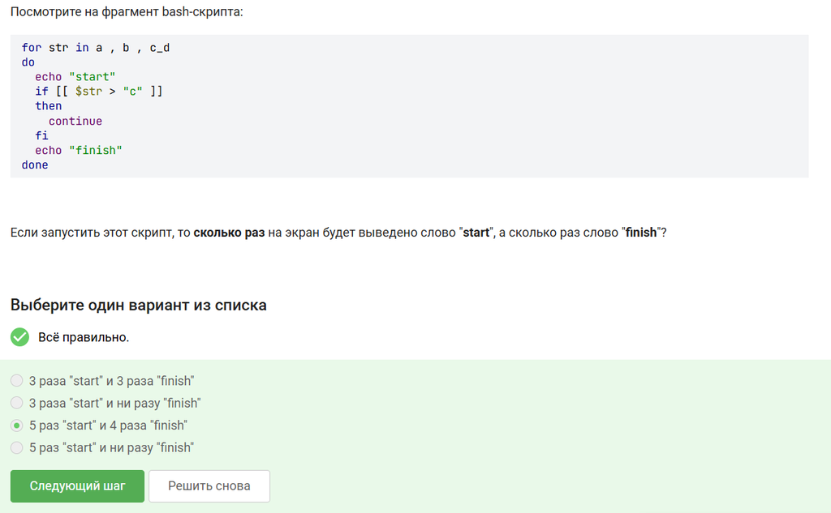

Рисунок 15: 14 задание

Все варианты корректно прибавляют b к a (рис. 16).

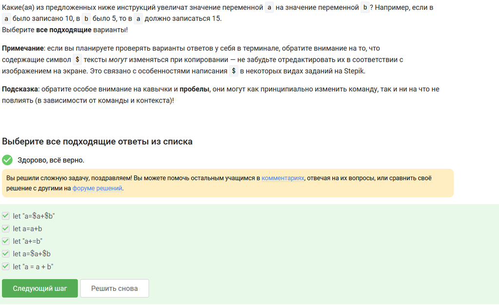

Рисунок 16: 15 задание

cd /home/bi/ меняет директорию, обратные кавычки выполняют pwd там, echo выводит /home/bi(рис. 17).

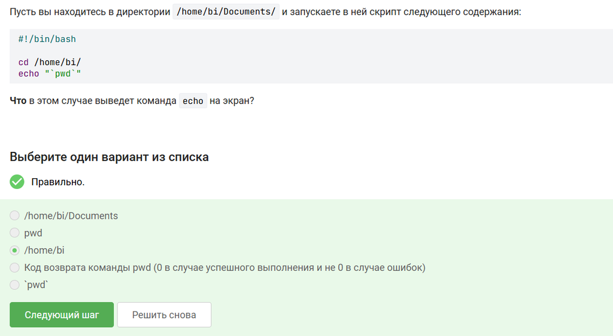

Рисунок 17: 16 задание

program; if [[ $? -eq 0 ]] — сохраняет код возврата. if program > some_file.txt — проверяет код, stdout в файл. Остальные пытаются использовать вывод вместо кода возврата (рис. 18).

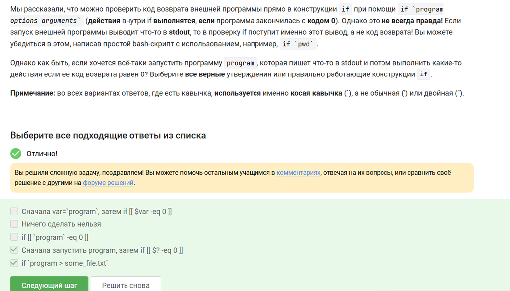

Рисунок 18: 17 задание

```
#!/bin/bash
gcd() {
  if [ $1 -eq $2 ]; then echo "GCD is $1"; return
  elif [ $1 -gt $2 ]; then gcd $(($1 - $2)) $2
  else gcd $1 $(($2 - $1)); fi
}
while read m n; do
  [ -z "$m" ] && echo "bye" && exit
  gcd $m $n
done
```

Построчно:

gcd() { — объявление функции

if [ $1 -eq $2 ]; then — если числа равны

echo “GCD is $1” — выводим НОД

return — выходим из функции

elif [ $1 -gt $2 ]; then — если первое больше второго

gcd $(($1 - $2)) $2 — вызываем gcd с разностью

else — иначе (второе больше первого)

gcd $1 $(($2 - $1)) — вызываем gcd с разностью

while read m n; do — читаем два числа

[ -z “$m” ] && echo “bye” && exit — если пустая строка, выводим bye и выходим

gcd $m $n — вызываем функцию

done — конец цикла (рис. 19, рис. 20).

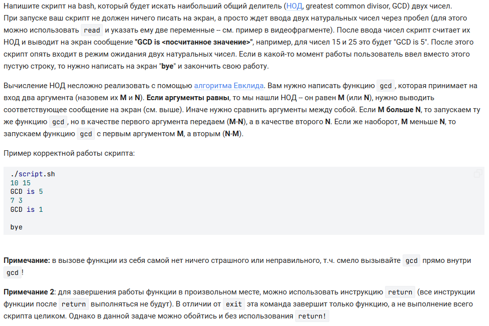

Рисунок 19: 18 задание

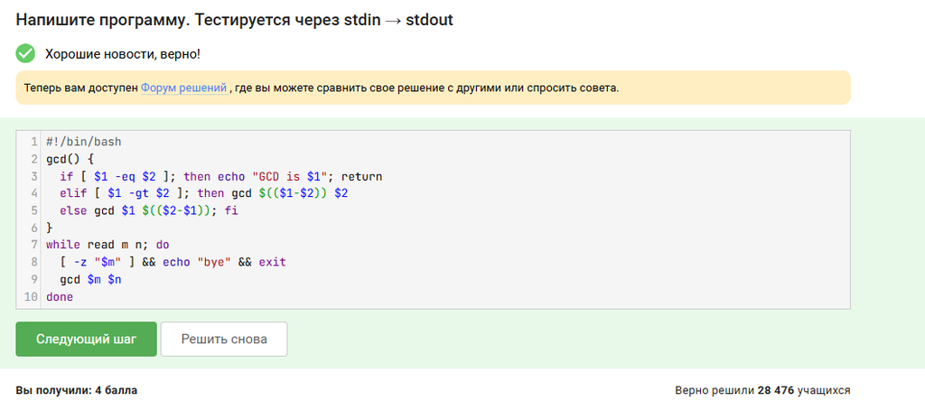

Рисунок 20: 18 задание

c1 — локальная, глобальная остаётся пустой (выводит пусто). c2 — глобальная, сумма 2×(1+2+…+10) = 110 (рис. 21).

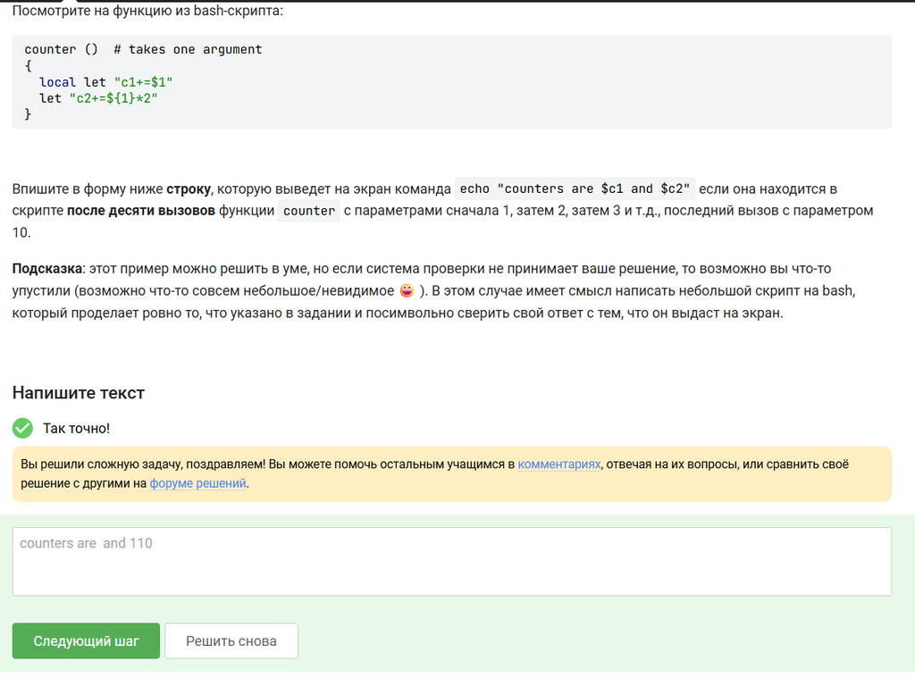

Рисунок 21: 19 задание

```
#!/bin/bash
while true;
do
    read a op b
    if [[ $a == "exit" ]];
    then
        echo "bye"
        exit
    elif [[ ! $a =~ ^[0-9]+$ || ! $b =~ ^[0-9]+$ ]];
    then
    echo "error"
    exit
    else
    case $op in
        "+") let "res = a + b" ;;
        "-") let "res = a - b" ;;
        "*") let "res = a * b" ;;
```

```
        "/") let "res = a / b" ;;
        "%") let "res = a % b" ;;
        "**") let "res = a ** b" ;;
        *) echo "error"; exit ;;
    esac
    echo "$res"
    fi
done
```

while true; do — бесконечный цикл

read a op b — читаем число, операцию, число

if [[ $a == “exit” ]]; then — если введено “exit”

echo “bye” — выводим bye, exit — выходим

elif [[ ! $a =~ ^[0-9]+$ || ! $b =~ ^[0-9]+$ ]]; then — если a или b не числа

echo “error”; exit — выводим error и выходим

case $op in — смотрим операцию

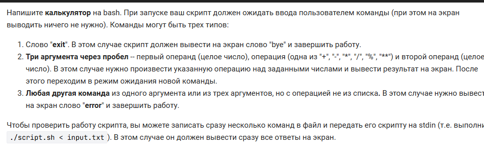

Рисунок 22: 20 задание

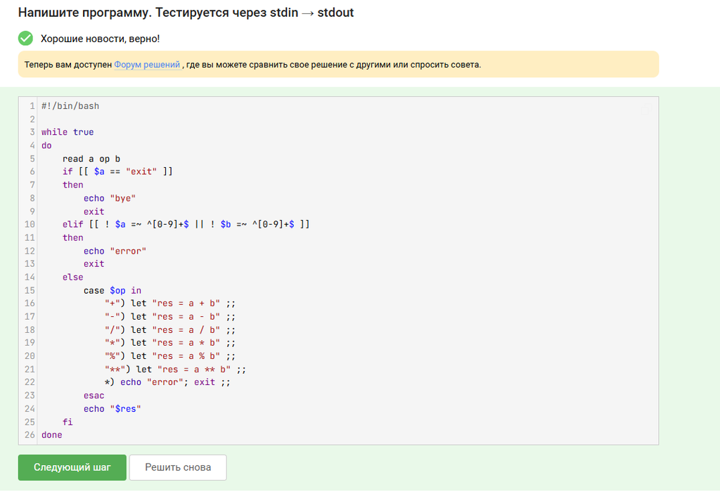

Рисунок 23: 20 задание

-iname без учёта регистра найдёт и STARS.txt, и Star_Wars.avi. -name — только с маленькой буквы, поэтому их не найдёт. Остальные файлы либо не начинаются на star, либо начинаются с маленькой star (найдутся обоими) (рис. 24).

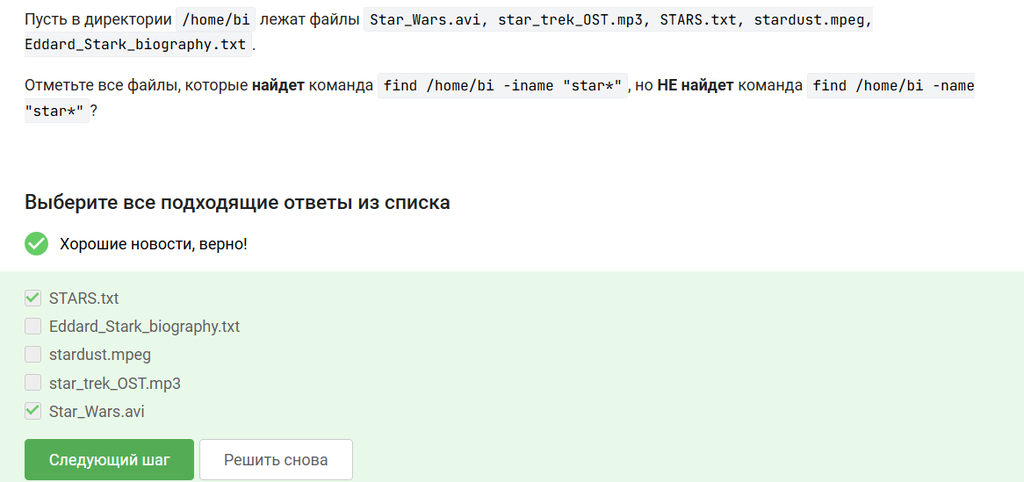

Рисунок 24: 21 задание

-name ищет только имя, -path — весь путь. Если файл с нужным именем лежит в подпапке, -path может найти его, а -name нет.(рис. 25).

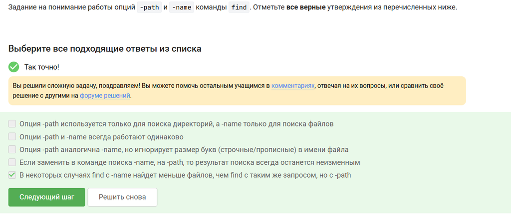

Рисунок 25: 22 задание

file1 — глубина 2. file2 — глубина 3. file3 — глубина 4 (не попадает в -maxdepth 3) (рис. 26).

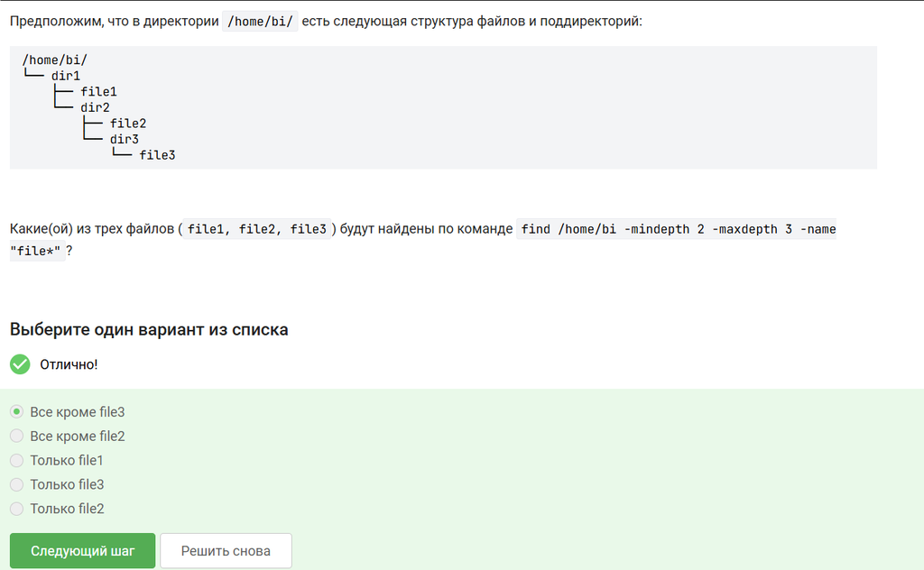

Рисунок 26: 23 задание

Для файла из 10 строк, где слово есть в каждой, -A 1, -B 1, -C 1 из-за границ файла не добавляют дополнительных строк. Все команды выведут 10 строк → размер одинаков.(рис. 27).

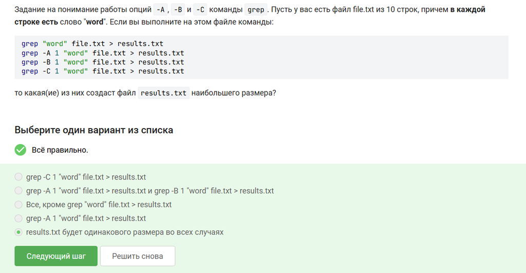

Рисунок 27: 24 задание

Шаблон: любой символ из xklXKL (необязательно), затем ubuntu в конце строки.